# Introduction à R - s3

31/05/2024

[figure not shown]

[figure not shown]

**L’utilisation :**

Ce document est préparé pour le workshop de R de CERMO-FC. Vous êtes libre de partager et d’utiliser ce matériel, mais veuillez citer la source.

## Boucle

Définie par le mot-clé *for*, qui permet d’effectuer plusieurs fois la même opération :

```r
listNames = list("Mina", "Sam", "Lynda")
for (name in listNames) {
  # print(name)
  print(paste("Bonjour", name, sep = " "))
}
```

```
## [1] "Bonjour Mina"
## [1] "Bonjour Sam"
## [1] "Bonjour Lynda"
```

Écrivez une boucle *for* qui itère sur les nombres de 1 à 7 et affiche le cube de chaque nombre en utilisant la fonction print() :

```r
for(i in c(1:7) ) {
  print(i^3)
}
```

```
## [1] 1
## [1] 8
## [1] 27
## [1] 64
## [1] 125
## [1] 216
## [1] 343
```

## Entrée / Sortie (gestion des fichiers)

### Répertoire de travail

Pour obtenir le répertoire de travail d’une session R, vous pouvez utiliser la fonction suivante :

```r
getwd()
```

La fonction `setwd(chemin)` est utilisée pour changer le répertoire de travail. Par exemple, la commande suivante change le répertoire de travail en “`C:/coursR`”.

```r
# Trois méthodes pour définir le chemin

setwd("C:/coursR") # Windows
# setwd("/Users/Name/coursR") # Mac ou Linux
```

### Voir la liste des fichiers

```r
lsFiles = list.files("files/")
lsFiles
```

```
##  [1] "andLogic.tsv"
##  [2] "authors.csv"
##  [3] "chr22_V39.bed"
##  [4] "hg38_refseq2.tsv"
##  [5] "listeNom"
##  [6] "listeNom.txt"
##  [7] "listNames.txt"
##  [8] "orLogic.tsv"
##  [9] "penguins.csv"
## [10] "penguinsDF_bill_depth_body_mass.png"
```

### *grepl()*

Recherche les correspondances avec le motif spécifié dans une chaîne de caractères :

```r
grepl("tsv","listeNom.txt")
```

```
## [1] FALSE
```

```r
grepl("t","listeNom.txt")
```

```
## [1] TRUE
```

```r
lsFiles[2]
```

```
## [1] "authors.csv"
```

```r
grepl("u",lsFiles[2])
```

```
## [1] TRUE
```

Dans *lsFiles*, imprimez tous les fichiers contenant **.tsv** :

```r
for(name in lsFiles) {
  if (grepl(".tsv", name)) {
    print(name)
  }
}
```

```
## [1] "andLogic.tsv"
## [1] "hg38_refseq2.tsv"
## [1] "orLogic.tsv"
```

Voir la liste des fichiers avec une extension **“.tsv”** ou **“.csv”** :

```r
for (i in 1:length(lsFiles)) {

  f = lsFiles[i]
  if (grepl(".tsv", f) || grepl(".csv", f) ) {
    print(f)
  }
}
```

```
## [1] "andLogic.tsv"
## [1] "authors.csv"
## [1] "hg38_refseq2.tsv"
## [1] "orLogic.tsv"
## [1] "penguins.csv"
```

### Importation de données depuis un fichier dans un *dataframe*

Pour lire directement un fichier externe et le stocker sous forme de dataframe, vous pouvez utiliser des fonctions d’importation spécifiques selon le format du fichier.

Par exemple :

#### `read.table()` pour les fichiers TSV (tabulaires)

Assurez-vous d’adapter les paramètres comme `header` et `sep` en fonction de la structure spécifique de vos fichiers de données :

```r
hg38_chr22 = read.table(file = "files/chr22_V39.bed", header = F, sep = "\t", row.names = NULL)
```

```r
head(hg38_chr22, n = 6L, addrownums = TRUE)
```

```
##      V1       V2       V3                V4 V5 V6
## 1 chr22 10736170 10736283 ENST00000615943.1  0  -
## 2 chr22 10939387 10961338 ENST00000635667.1  0  -
## 3 chr22 11066417 11068174 ENST00000624155.2  0  +
## 4 chr22 11124336 11125705 ENST00000422332.1  0  +
## 5 chr22 11249808 11249959 ENST00000612732.1  0  -
## 6 chr22 11474743 11479643 ENST00000672261.1  0  +
```

Trouvez les paramètres pour chaque fonction dans R.

#### `read.csv()` pour lire les fichiers CSV (colonnes séparés par des virgules) :

```r
penguins = "files/penguins.csv"
penguinsDF = read.csv(penguins, header = T, row.names = NULL)
```

```r
tail(penguinsDF, n = 6L, keepnums = TRUE)
```

```
##       species island bill_length_mm bill_depth_mm flipper_length_mm body_mass_g    sex year
## 339 Chinstrap  Dream           45.7          17.0               195        3650 female 2009
## 340 Chinstrap  Dream           55.8          19.8               207        4000   male 2009
## 341 Chinstrap  Dream           43.5          18.1               202        3400 female 2009
## 342 Chinstrap  Dream           49.6          18.2               193        3775   male 2009
## 343 Chinstrap  Dream           50.8          19.0               210        4100   male 2009
## 344 Chinstrap  Dream           50.2          18.7               198        3775 female 2009
```

```r
penguinsDF2 = read.table(file = "files/penguins.csv", header = F, sep = ",", row.names = NULL)
```

```r
head(penguinsDF2, n = 6L, keepnums = TRUE)
```

```
##        V1        V2             V3            V4                V5          V6     V7   V8
## 1 species    island bill_length_mm bill_depth_mm flipper_length_mm body_mass_g    sex year
## 2  Adelie Torgersen           39.1          18.7               181        3750   male 2007
## 3  Adelie Torgersen           39.5          17.4               186        3800 female 2007
## 4  Adelie Torgersen           40.3            18               195        3250 female 2007
## 5  Adelie Torgersen           <NA>          <NA>              <NA>        <NA>   <NA> 2007
## 6  Adelie Torgersen           36.7          19.3               193        3450 female 2007
```

#### Lecture de fichiers CSV avec métadonnées, lignes commentées et lignes vides :

```r
inst <- read.csv("files/listeNom.txt",comment.char="#",skip=5)
head(inst, n = 10L) # la valeur par défaut est 6L.
```

```
##   firstname   lastname       id                        inst
## 1       Jon        Doe     jdoe             Université de A
## 2      Doug      Smith   dsmith             Université de B
## 3       Jen     Dunbar  jdunbar             Université de C
## 4      Jeff         Wu   jeffwu           Institut de l'ABC
## 5     Boris    Wronski bwronski Université d'État de Moscou
## 6    Joseph    Wronski jwronski           Institut de l'ABC
## 7     Maria Mickiewicz   mariam             Université de X
```

On peut insérer un *#* devant une ligne pour la marquer comme une ligne commentée, une ligne qui ne doit pas être incluse dans les données. On peut utiliser l’option `comment.char = "#"` pour sauter de telles lignes. Par exemple, dans le fichier *authors.csv*, la cinquième ligne est commentée :

```r
authors <- read.csv("files/authors.csv",comment.char="#")
authors
```

```
##   firstname lastname       id                       title year
## 1       Jon      Doe     jdoe                 How to cook 2000
## 2      Doug    Smith   dsmith           Making money fast 1999
## 3       Jen   Dunbar  jdunbar              Thinking twice 2018
## 4      Gary  Dickson gdickson  Introduction to statistics 2019
## 5     Boris  Wronski bwronski How to make perfect pancake 2019
```

### Première visualisation des données

Visualisez les premières lignes avec `head()`. Cela permet de vérifier rapidement que l’importation s’est bien déroulée, qu’aucune anomalie n’apparaît dans les variables et que les valeurs numériques sont bien reconnues.

### `str()` fournit un affichage compact de la structure d’un objet R

```r
str(hg38_chr22)
```

```
## 'data.frame':    5248 obs. of  6 variables:
##  $ V1: chr  "chr22" "chr22" "chr22" "chr22" ...
##  $ V2: int  10736170 10939387 11066417 11124336 11249808 11474743 11827522 11883601 12602465 15273854 ...
##  $ V3: int  10736283 10961338 11068174 11125705 11249959 11479643 11910358 11904000 12626642 15273961 ...
##  $ V4: chr  "ENST00000615943.1" "ENST00000635667.1" "ENST00000624155.2" "ENST00000422332.1" ...
##  $ V5: int  0 0 0 0 0 0 0 0 0 0 ...
##  $ V6: chr  "-" "-" "+" "+" ...
```

### `dim()`

```r
dim(hg38_chr22)
```

```
## [1] 5248    6
```

### Autres opérations d’exploration des données

`names()` noms de colonnes :

```r
names(hg38_chr22)
```

```
## [1] "V1" "V2" "V3" "V4" "V5" "V6"
```

`summary()` résumé des variables :

```r
summary(hg38_chr22)
```

```
##       V1                  V2                 V3                V4                  V5         V6
##  Length:5248        Min.   :10736170   Min.   :10736283   Length:5248        Min.   :0   Length:5248
##  Class :character   1st Qu.:23567063   1st Qu.:23573411   Class :character   1st Qu.:0   Class :character
##  Mode  :character   Median :31753898   Median :31773954   Mode  :character   Median :0   Mode  :character
##                     Mean   :32769655   Mean   :32796936                      Mean   :0
##                     3rd Qu.:41110460   3rd Qu.:41132496                      3rd Qu.:0
##                     Max.   :50798654   Max.   :50801309                      Max.   :0
```

## Manipulation des dataframes

### Renommer les colonnes

```r
head(hg38_chr22)
```

```
##      V1       V2       V3                V4 V5 V6
## 1 chr22 10736170 10736283 ENST00000615943.1  0  -
## 2 chr22 10939387 10961338 ENST00000635667.1  0  -
## 3 chr22 11066417 11068174 ENST00000624155.2  0  +
## 4 chr22 11124336 11125705 ENST00000422332.1  0  +
## 5 chr22 11249808 11249959 ENST00000612732.1  0  -
## 6 chr22 11474743 11479643 ENST00000672261.1  0  +
```

```r
colnames(hg38_chr22)
```

```
## [1] "V1" "V2" "V3" "V4" "V5" "V6"
```

```r
colnames(hg38_chr22) = c("chrom", "start", "stop","EnsembleID", "score", "orientation")
```

### Sélection des données

```r
hg38_chr22_select = hg38_chr22[1:4]
head(hg38_chr22_select)
```

```
##   chrom    start     stop        EnsembleID
## 1 chr22 10736170 10736283 ENST00000615943.1
## 2 chr22 10939387 10961338 ENST00000635667.1
## 3 chr22 11066417 11068174 ENST00000624155.2
## 4 chr22 11124336 11125705 ENST00000422332.1
## 5 chr22 11249808 11249959 ENST00000612732.1
## 6 chr22 11474743 11479643 ENST00000672261.1
```

### Ajout d’une constante

Supposons que les calculs sont incorrects en raison du grand nombre de 0 et que nous devons ajouter une unité au jeu de données :

```r
hg38_chr22$score = hg38_chr22$score + 1
head(hg38_chr22$score)
```

```
## [1] 1 1 1 1 1 1
```

### Ajouter et supprimer des lignes et des colonnes

#### Ajouter une colonne

Nous souhaitons ajouter une colonne contenant la taille de chaque gène :

```r
hg38_chr22$size <- hg38_chr22$stop - hg38_chr22$start + 1
head(hg38_chr22)
```

```
##   chrom    start     stop        EnsembleID score orientation  size
## 1 chr22 10736170 10736283 ENST00000615943.1     1           -   114
## 2 chr22 10939387 10961338 ENST00000635667.1     1           - 21952
## 3 chr22 11066417 11068174 ENST00000624155.2     1           +  1758
## 4 chr22 11124336 11125705 ENST00000422332.1     1           +  1370
## 5 chr22 11249808 11249959 ENST00000612732.1     1           -   152
## 6 chr22 11474743 11479643 ENST00000672261.1     1           +  4901
```

#### Supprimer une colonne

Un exemple pour supprimer une colonne (la colonne 5) :

```r
hg38_chr22[,5] = NULL
# hg38_chr22$score = NULL
# ou
hg38_chr22[1:10, -6]
```

```
##    chrom    start     stop        EnsembleID orientation
## 1  chr22 10736170 10736283 ENST00000615943.1           -
## 2  chr22 10939387 10961338 ENST00000635667.1           -
## 3  chr22 11066417 11068174 ENST00000624155.2           +
## 4  chr22 11124336 11125705 ENST00000422332.1           +
## 5  chr22 11249808 11249959 ENST00000612732.1           -
## 6  chr22 11474743 11479643 ENST00000672261.1           +
## 7  chr22 11827522 11910358 ENST00000657566.1           +
## 8  chr22 11883601 11904000 ENST00000657645.1           +
## 9  chr22 12602465 12626642 ENST00000634617.1           +
## 10 chr22 15273854 15273961 ENST00000613107.1           +
```

#### Ajouter une ligne

```r
dim(hg38_chr22)
```

```
## [1] 5248    6
```

```r
hg38_chr22[5249,] = hg38_chr22[5248,]
```

```r
tail(hg38_chr22)
```

```
##      chrom    start     stop        EnsembleID orientation size
## 5244 chr22 50783796 50789296 ENST00000689655.1           + 5501
## 5245 chr22 50783796 50789353 ENST00000494075.5           + 5558
## 5246 chr22 50783809 50789244 ENST00000423888.6           + 5436
## 5247 chr22 50783874 50789186 ENST00000686022.1           + 5313
## 5248 chr22 50798654 50799123 ENST00000427528.1           +  470
## 5249 chr22 50798654 50799123 ENST00000427528.1           +  470
```

## Fusionner des dataframes

```r
xA = c("A1", "A2", "A3")
xB = c("B1", "B2", "B3")
xC = c("C1", "C2", "C3")

x = data.frame(xA, xB, xC)
names(x) = c("A", "B", "C")
x
```

```
##    A  B  C
## 1 A1 B1 C1
## 2 A2 B2 C2
## 3 A3 B3 C3
```

```r
yB = c("B2", "B3", "B5", "B6")
yF = c("F2", "F3", "F5", "F6")

y = data.frame(yB, yF)
names(y) = c("B", "F")
y
```

```
##    B  F
## 1 B2 F2
## 2 B3 F3
## 3 B5 F5
## 4 B6 F6
```

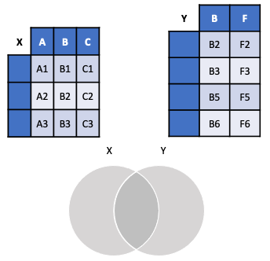

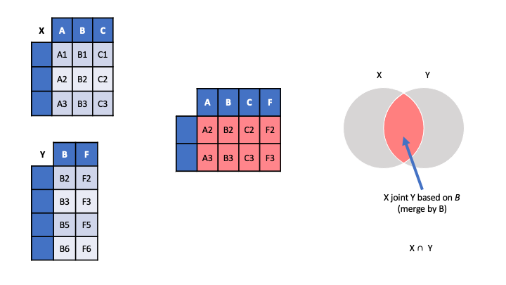

Pour obtenir l’intersection des deux dataframes ainsi que tous les éléments du premier dataframe (x), vous pouvez utiliser la fonction `merge()` avec l’option `all.x = TRUE` :

```r
merge(x, y, by = "B", all.x = TRUE)
```

```
##    B  A  C    F
## 1 B1 A1 C1 <NA>
## 2 B2 A2 C2   F2
## 3 B3 A3 C3   F3
```

Pour obtenir l’intersection des deux dataframes plus tous les éléments du deuxième dataframe (y), vous pouvez utiliser la fonction `merge()` avec l’option `all.y = TRUE` :

```r
merge(x, y, by = "B", all.y=TRUE)
```

```
##    B    A    C  F
## 1 B2   A2   C2 F2
## 2 B3   A3   C3 F3
## 3 B5 <NA> <NA> F5
## 4 B6 <NA> <NA> F6
```

```r
head(hg38_chr22)
```

```
##   chrom    start     stop        EnsembleID orientation  size
## 1 chr22 10736170 10736283 ENST00000615943.1           -   114
## 2 chr22 10939387 10961338 ENST00000635667.1           - 21952
## 3 chr22 11066417 11068174 ENST00000624155.2           +  1758
## 4 chr22 11124336 11125705 ENST00000422332.1           +  1370
## 5 chr22 11249808 11249959 ENST00000612732.1           -   152
## 6 chr22 11474743 11479643 ENST00000672261.1           +  4901
```

```r
geneNames = read.table(file = "files/hg38_refseq2.tsv", header = T, sep = "\t", row.names = NULL)
head(geneNames)
```

```
##           EnsembleID      mRNA   spID  spDisplayID geneSymbol    refseq   protAcc
## 1 ENST00000000233.10 NM_001662 P84085   ARF5_HUMAN       ARF5 NM_001662 NM_001662
## 2  ENST00000000412.8 NM_002355 P20645   MPRD_HUMAN       M6PR NM_002355 NM_002355
## 3 ENST00000000442.11 NM_004451 Q569H8 Q569H8_HUMAN      ESRRA NM_004451 NM_004451
## 4  ENST00000001008.6 NM_002014 Q02790  FKBP4_HUMAN      FKBP4 NM_002014 NM_002014
## 5  ENST00000001146.7 NM_019885 Q9NR63  CP26B_HUMAN    CYP26B1 NM_019885 NM_019885
## 6  ENST00000002125.9 NR_146409 Q7L592   MIDA_HUMAN    NDUFAF7 NR_146409 NR_146409
```

```r
dim(hg38_chr22)
```

```
## [1] 5249    6
```

```r
hg38_chr22_names = merge(hg38_chr22, geneNames[,c("EnsembleID","geneSymbol", "mRNA")], by = "EnsembleID", all.x=TRUE)
dim(hg38_chr22_names)
```

```
## [1] 5249    8
```

### Exporter vers un fichier

Pour écrire le contenu du data frame dans un fichier :

```r
write.table(hg38_chr22_names, file="outputs/hg38_V39_modif.tsv",sep="\t")
```

## Visualisation des données

Tracer la longueur du bec (bill_length) du dataframe penguinsDF :

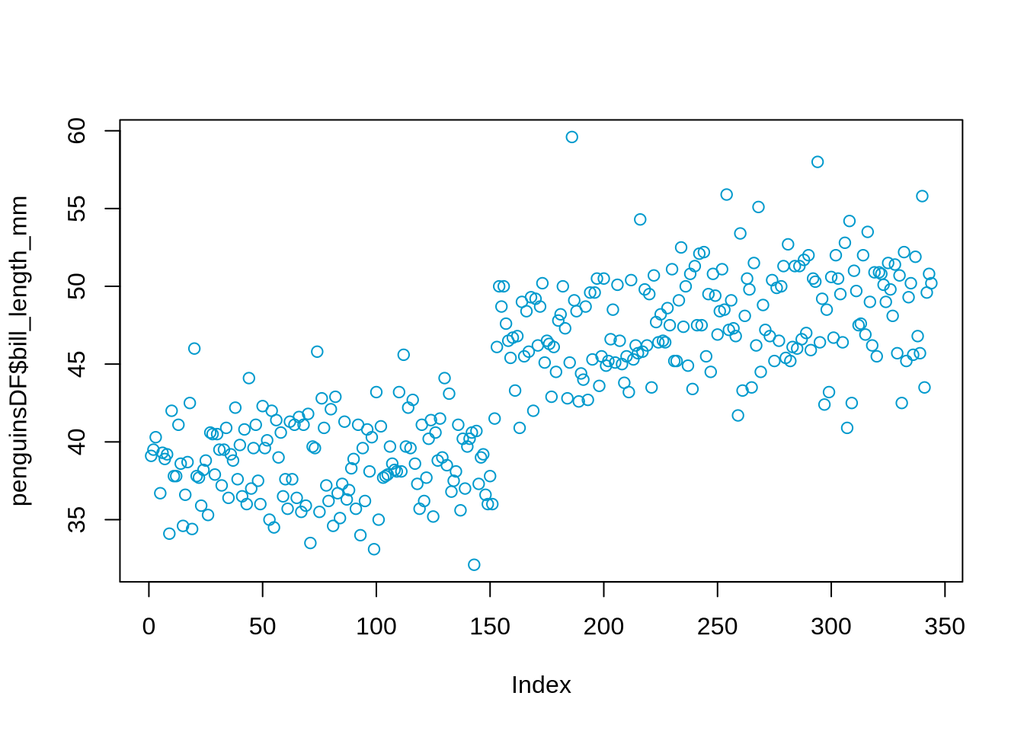

```r
plot(penguinsDF$bill_length_mm, col="deepskyblue3")
```

Tracer la profondeur du bec (bill_depth) :

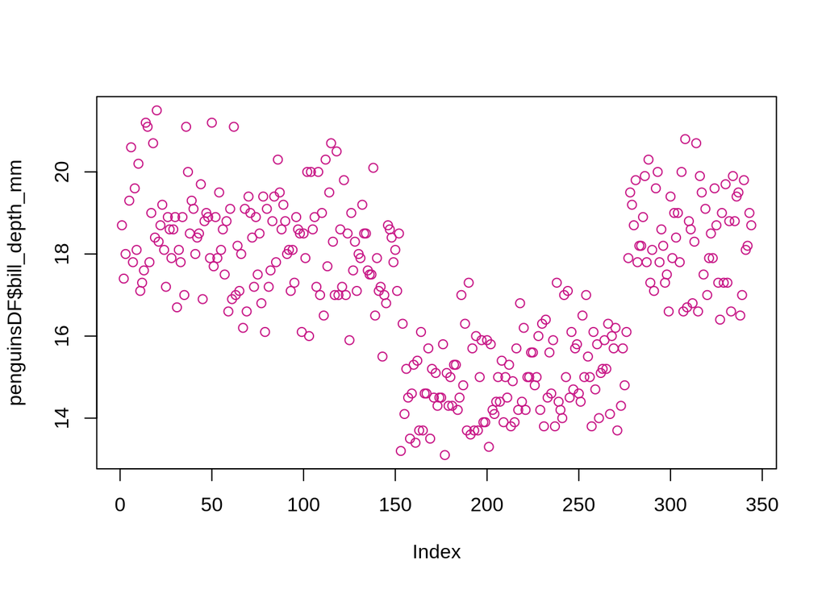

```r
plot(penguinsDF$bill_depth_mm, col="mediumvioletred")
```

Tracer *body_mass* par rapport à *flipper_length* :

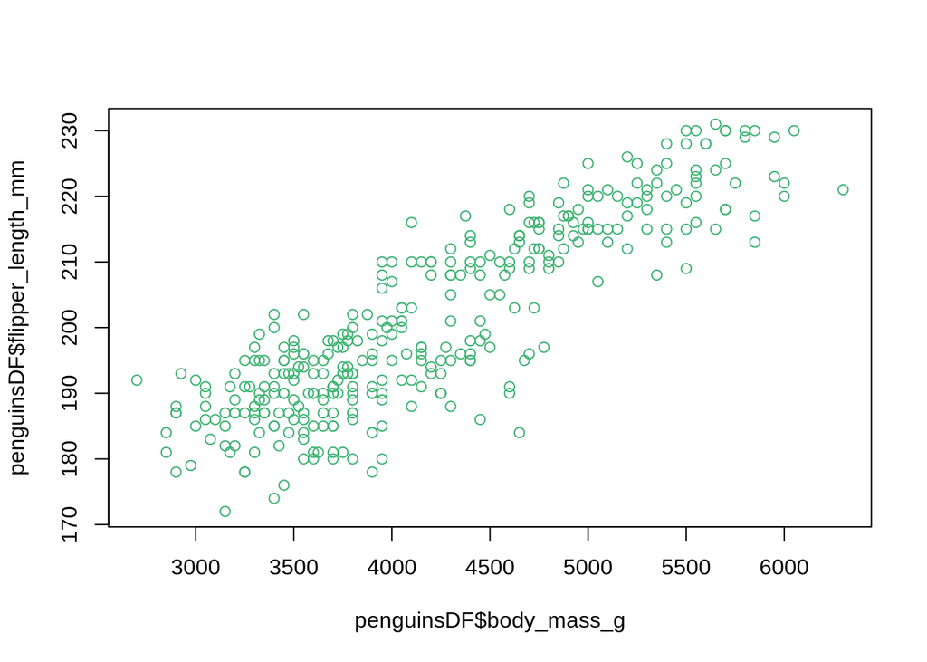

```r
plot(penguinsDF$body_mass_g, penguinsDF$flipper_length_mm, col = "mediumseagreen")
```

Tracer un boxplot de *body_mass* par rapport à *sex* :

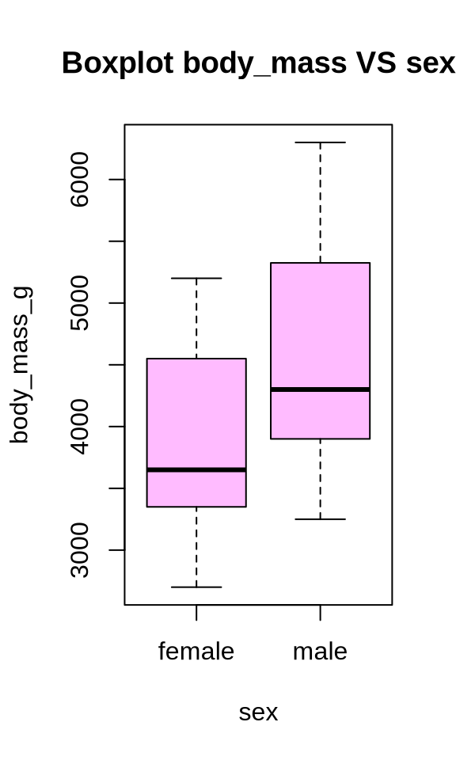

```r
boxplot(body_mass_g ~ sex, data = penguinsDF, col = "plum1", main = "Boxplot body_mass VS sex")
```

Tracer un barplot des colonnes 3 à 6 de penguinsDF :

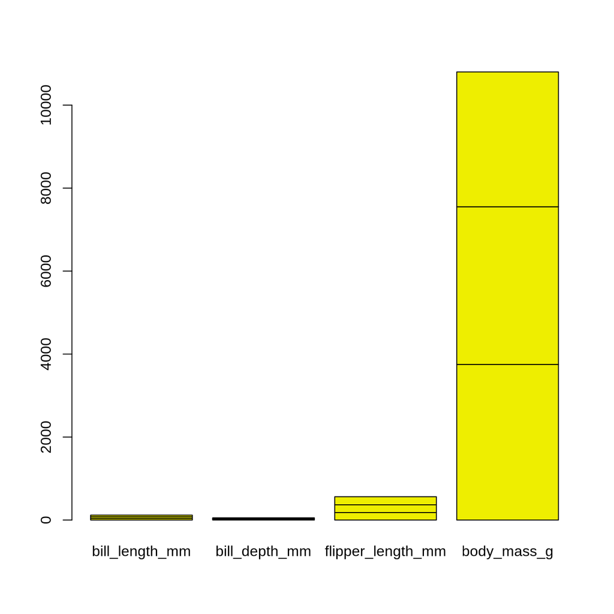

```r
penguinsDF_select = as.matrix(penguinsDF[,3:6])
barplot(height = penguinsDF_select,  col= "yellow2")
```

### Library de ggplot2

Pour la visualisation des données, le package ggplot2 produit des graphiques plus élégants que les fonctions de base de R et offre un moyen plus pratique de contrôler l’effet de visualisation avec des paramètres.

Le package ggplot2 peut être facilement installé en utilisant la fonction R `install.packages()`. Après avoir installé le package, vous pouvez le charger en utilisant la fonction R `library()` :

```r
# install.packages("ggplot2")
# Load ggplot2
library("ggplot2")
```

Point plot avec ggplot :

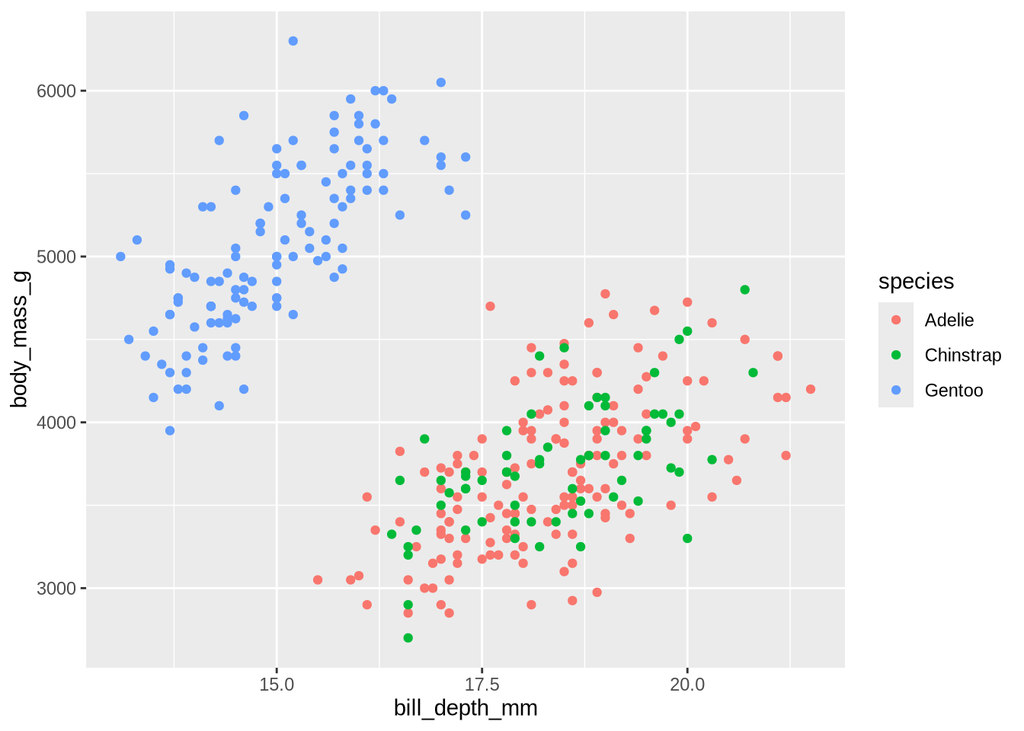

```r
ggplot(data = penguinsDF, mapping = aes(x = bill_depth_mm, y = body_mass_g)) +
  geom_point( aes(color = species))
```

Enregistrez le graphique dans un fichier *.png* :

```r
filePNG = "outputs/penguinsDF_bill_depth_body_mass.png"
png(file = filePNG, width=600, height=500)
ggplot(data = penguinsDF, mapping = aes(x = bill_depth_mm, y = body_mass_g)) +
  geom_point( aes(color = species))
dev.off()
```

## Données manquantes

Vous pouvez avoir des champs dans un vecteur, une matrice ou un dataframe qui n’ont pas de valeur (`NULL`). En R, les données manquantes sont représentées par `NA`. La plupart des fonctions R peuvent bien gérer les `NA` dans leurs calculs. Par exemple, la fonction `sum()` a une option pour supprimer les `NA` lors de l’addition des nombres. Nous pouvons également les remplacer par d’autres valeurs :

```r
vecGene = c("NBR1", "1A13B", "KIAA0049", "M17S2", "MIG19")
length(vecGene)
```

```
## [1] 5
```

Insérer une valeur à une position qui n’existe pas. Que se passe-t-il ?

```r
vecGene[7] = "CALC1"
vecGene[10] = "KNL1"
vecGene
```

```
##  [1] "NBR1"     "1A13B"    "KIAA0049" "M17S2"    "MIG19"    NA         "CALC1"    NA         NA         "KNL1"
```

Nous pouvons tester la présence de données manquantes avec `is.na()` :

```r
is.na(vecGene)
```

```
##  [1] FALSE FALSE FALSE FALSE FALSE  TRUE FALSE  TRUE  TRUE FALSE
```

```r
which(is.na(vecGene))
```

```
## [1] 6 8 9
```

Remplacer les `NA` par une autre valeur (par exemple “-”) :

```r
vecGene[is.na(vecGene)] = "-"
vecGene
```

```
##  [1] "NBR1"     "1A13B"    "KIAA0049" "M17S2"    "MIG19"    "-"        "CALC1"    "-"        "-"        "KNL1"
```

```r
paiments = c(200,150, 499)
paiments[5] = 600
paiments[9] = 200
paiments
```

```
## [1] 200 150 499  NA 600  NA  NA  NA 200
```

```r
paiments[is.na(paiments)] = 0
paiments
```

```
## [1] 200 150 499   0 600   0   0   0 200
```

Voir aussi `NaN` et `Inf`: `is.finite()` et `is.infinite()`.

## End of session 3

**Références:**

Ce document est basé sur les notes de cours “Course_1_intro_R” (préparé par Golrokh Kiani) ainsi que sur du matériel gratuit sur internet:

https://www.tutorialspoint.com  
https://scilifelab.github.io/courses/r_programming/1611/Exercises/Vectors  
https://www.r-exercises.com  
https://www.datamentor.io/r-programming/  
https://training.computeontario.ca  
https://www.w3schools.com/  
http://www.r-tutor.com/